# Study 3

```r
# Chunk Options
knitr::opts_chunk$set(echo=TRUE, message=FALSE, warning=FALSE)

# Load packages
library(broom)
library(tidyverse)
library(codebook) # to generate codebook
library(here)
library(car) # for the type III SS in ANOVA
library(emmeans)
library(effectsize) # for equivalence tests and effect size estimation
library(GGally) # for ggpairs
library(apastats)
library(ggmosaic)
library(ggpubr)
library(ggtext) # element_markdown
source(here("r", "namifunc.R")) # Read User-Defined Functions

# Load Public Data  ----------------------------------------
s3_df <- read_rds(here("data_public", "Study3_public.rds")) %>% filter(Finished == 1)
```

```r
# Descriptives table - Means and SDs for measured scores by condition
s3_df_msd <- s3_df %>% describe_by_factor(parasocial, social_world,
                                          vars = c(T1_Heart_1, T1_Valence_1, T1_Arousal_1, T1_Dominance_1,
                                                   T2_Heart_1, T2_Valence_1, T2_Arousal_1, T2_Dominance_1,
                                                   IOS, Single_Immersion,
                                                   OTF_Social_World, Enjoyment)) %>%
  # Clean Names
  rename_all(.funs = ~str_replace(., "_1_", "_"))

# Means and Standard Devisions for Each conditions
s3_df_msd <- get_APA_from_msd(s3_df_msd) %>% data.table::setDT(key = c("parasocial", "social_world", "variable", "APA"))
```

# 1 Participants

```r
# Getting participants per condition
s3_ntable <- s3_df %>% group_by(parasocial, social_world) %>%
  summarise(n = n()) %>% mutate(key = str_c(str_extract(parasocial, "^."), str_extract(social_world, "^.")))
s3_n_txt <- s3_ntable %>% ungroup %>% select(key, n) %>% deframe %>% as.list() %>%
  append(list(all_participated = s3_ntable$n %>% sum))

# Exclusions by Attention Check
s3_attention_df <- s3_df %>% group_by(attention_all_correct) %>%
  summarise(n = n())

s3_atteion_by_group <- s3_df %>%
  transmute(attention_rejection_only = !attention_rejection_correct & attention_parasocial_correct & attention_social_world_correct,
            attention_parasocial_only = attention_rejection_correct & !attention_parasocial_correct & attention_social_world_correct,
            attention_social_world_only = attention_rejection_correct & attention_parasocial_correct & !attention_social_world_correct,
            attention_all = !attention_rejection_correct & !attention_parasocial_correct & !attention_social_world_correct) %>% summarise(across(everything(), sum))


# Create a df with included participants
s3_included <- s3_df %>% filter(attention_all_correct == TRUE)
```

The current study used a novel RPG with a fictional story with dialogues with non-player characters—both important components for the parasocial relationship and social world manipulations. However, some people may dislike stories and dialogues and ignore them in their gameplay. If I happen to recruit only participants disinterested in stories, the manipulations in this study will be ineffective simply because they are not paying attention to the manipulation. To minimize the issue, I will ask prospective participants to answer the story subscale of the Gaming Attitudes, Motives, and Experiences Scale to measure people’s interests in stories in video games (Hilgard et al., 2013). Then, I will prioritize inviting participants with higher interests in stories for participation.

Prioritizing the participation of people who like storytelling will also increase the external validity of the study. In reality, single-player video games with social surrogates are usually role-playing games with stories and dialogues with other characters. People who regularly play these games should have interests in stories in the first place since people usually purchase and play video games they like. If I happen to only recruit participants who dislike stories, our sample will not be representative of the consumers of single-player video games with social surrogates. The results of the study will have the most implications for those who are likely to play single-player video games–prioritizing their participation will increase the generality and impact of the study in the long run.

# 2 Materials and Procedure

# 3 Measures

# 4 Results

```r
# Main Analysis - Main ANOVA Model
ANOVA_lm <- s3_df %>%
  # Include only those who passed the attention check
  filter(attention_all_correct == TRUE) %>%
  # 2 (Parasocial) x 2 (Social World) ANOVA on Heart Manikin Scores at Time 2
  lm(formula = T2_Heart_1 ~ parasocial * social_world,
     data = .)
# Summary for linear model (Type III SS)
ANOVA_summary <- car::Anova(ANOVA_lm, type = 3)
# Estimated Marginal MEans
ANOVA_EM <- emmeans(ANOVA_lm, pairwise ~ parasocial:social_world, level = .90)
# Pairs contrasts
ANOVA_EM_tibble <- ANOVA_EM$contrasts %>% as_tibble()
# Add APA Stats Emeans
ANOVA_EM_tibble  <- ANOVA_EM_tibble %>%
  mutate(APA = ANOVA_EM_tibble %>% describe.emmeans(dtype = "t"))
# get a list of APA
s3_contratsts_APA <- ANOVA_EM_tibble %>% select(contrast, APA) %>%
  # abbreviate the contrast labels
  mutate(contrast = abbreviate(contrast)) %>%
  deframe %>%  as.list


# Plot the predicted means from the ANOVA model
# emmip(ANOVA_lm, social_world ~ parasocial, CIs = TRUE) + xlab("Parasocial Relationship")

# Main Analysis -  Equivalence Testing

# # Approximation of Cohen's d, use .90 level for TOST - assuming equal group sizes (Not Use)
# ANOVA_EM_D <- t_to_d(t = ANOVA_EM_tibble$t.ratio, df_error = ANOVA_EM_tibble$df[[1]], ci = .90)
# # Equivalence test using d (`equivalence_test.effectsize_table`)
# ANOVA_EM_D %>% equivalence_test(range = c(-Cohen_d_target, Cohen_d_target))

# Standardized effect sizes (True Cohen's d)
ANOVA_cohen <- eff_size(ANOVA_EM, sigma(ANOVA_lm), df.residual(ANOVA_lm),
                        level = .90)
# Convert to tibble for plotting
ANOVA_cohen_tibble <- ANOVA_cohen %>% as_tibble()
# Shortened Labels for forestplot
ANOVA_cohen_tibble <- ANOVA_cohen_tibble %>%
  mutate(labels = str_split(contrast, " - "),
         label1 = map_chr(labels, ~.[[1]]),
         label2 = map_chr(labels, ~.[[2]])) %>%
  mutate(across(c(label1,label2), ~str_remove(., "\\(|\\)"))) %>%
  mutate(across(c(label1, label2), ~str_replace(., "Parasocial", "Para"))) %>%
  mutate(across(c(label1, label2), ~str_replace(., "Social World", "Social"))) %>%
  mutate(plot_label = paste(label1, label2, sep = " - "),
         key = abbreviate(plot_label)) %>%
  # APA-formatted results
  mutate(APA = sprintf("_d_ = %s, 90%%CI [%s, %s]",
                       effect.size %>% f.round(), lower.CL %>% f.round() , upper.CL %>% f.round()))

# Cohen's d's - Forestplot - Study 3
# Adding a table to the left https://stackoverflow.com/questions/12318120/adding-table-within-the-plotting-region-of-a-ggplot-in-r
s3_cohensd_forestplot <- ANOVA_cohen_tibble %>%
  ggplot(aes(y = plot_label, x = effect.size,
             xmin = lower.CL, xmax = upper.CL)) +
  # Vertical Lines for SESOI and Zero
  geom_zeroSEOI_d +
  # Add data points
  geom_point() +
  # Add the CI error bars
  geom_errorbarh(height = .5)+
  # Label: x-axis
  scale_x_continuous(name='Cohen\'s d') +
  # Label: y-axis
  ylab('Contrasts') +
  # Label: Title
  ggtitle("Effect Sizes for Contrasts at T2 Heart Manikin Scores") +
  labs(caption = "Errorbars represent 90% confidence intervals.")

# APA list for Study 3 results
ANOVA_summary_df <- ANOVA_summary %>% broom::tidy()
s3_results_main <- list(
  parasocial = ANOVA_summary_df %>% filter(term == "parasocial"),
  social_world = ANOVA_summary_df %>% filter(term == "social_world"),
  df_res = ANOVA_summary$Df[[5]] # alternatively, use `tail(vector, n = 1)`
)

# Describe by apastats and get a list of F values
s3_ANOVA_APA <- describe.Anova(ANOVA_summary)
names(s3_ANOVA_APA) <- ANOVA_summary %>% rownames()
s3_ANOVA_APA <- s3_ANOVA_APA %>% as.list()

# Cohen's d for the main effects (Parascoial and Social World)
s3_main_effects <- tibble(predictor = c("parasocial", "social_world")) %>%
  mutate(formula = sprintf("T2_Heart_1 ~ %s", predictor)) %>%
  mutate(ci90 = map(formula, ~effectsize::cohens_d(x = formula(.), data = s3_df, ci = .90))) %>%
  mutate(ci95 = map(formula, ~effectsize::cohens_d(x = formula(.), data = s3_df, ci = .95))) %>%
  mutate(equivalence = map(ci90, ~equivalence_test(., range = c(-Cohen_d_target, Cohen_d_target)))) %>%
  mutate(APA = map_chr(ci90, describe_d_ci)) %>%
  unnest(c(ci90, ci95), .sep = "_")
# APA results
s3_main_effects_APA <- s3_main_effects %>% select(predictor, APA) %>% deframe %>%
  as.list

# Get the cohens'd and the 90% ci for APA
s3_contratsts_d_APA <- ANOVA_cohen_tibble %>% select(key, APA) %>% deframe %>% as.list
```

**Main Analysis**. I ran a 2 (Parasocial Relationships: High vs. Low) x 2 (Social Worlds: High vs. Low) ANOVA on the Heart Manikin scores at Time 2. Contrary to the predictions, I did not observe the main effect of the parasocial relationships (Hypothesis 2) (*F*(1, 281) = 0.32, *p* = .570), and the main effect of the social worlds (Hypothesis 3; *F*(1, 281) = 0.64, *p* = .426). Similarly, I also did not observe the Parasocial Relationships x Social Worlds interaction effect (*F*(1, 281) = 0.03, *p* = .864). As a planned contrast, I compared the belonging scores of those in the Low Parasocial Relationships and Low Social Worlds condition to those in the High Parasocial Relationships and High Social Worlds condition to test Hypothesis 4. Results did not show a difference in Heart Manikin Scores at Time 2 (*t* = -1.05, *p* = .719). Figure 4.1 A.

Since the obtained p-values were greater than .05 for the analyses for Hypotheses 2, 3, and 4, I performed the two one-sided test of equivalence, consistent with the procedure in Study 2 (Lakens, 2017). Again all effect sizes smaller than |*d*| = 0.35 are considered theoretically equivalent to zero. The 90% confidence intervals fell within the SESOI for the main effect of the parasocial realationships *d* = -0.14, 90%CI [-0.31, 0.03] and the main effect of social world *d* = -0.11, 90%CI [-0.28, 0.06]. The Cohen’s d contrasting the High Parasocial-High Social World and the Low Parasocial-Low Social World contained the SESOI, and thus the results were ambiguous *d* = -0.18, 90%CI [-0.46, 0.10]. These results suggest that the main effects of parasocial relationships and social world were theoretically equivalent to zero.

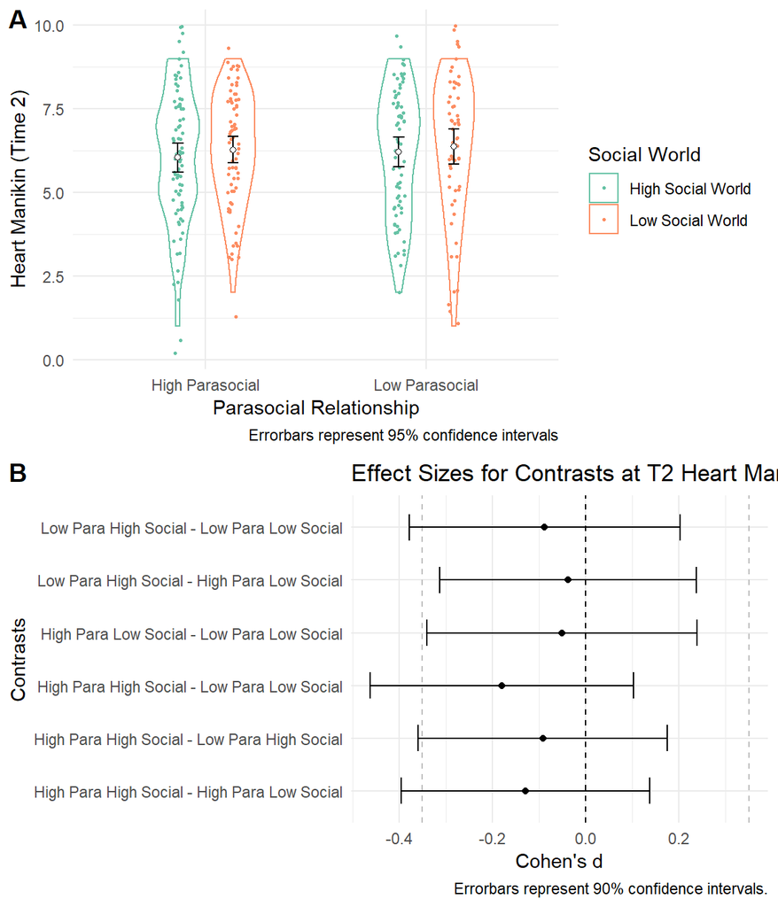

Figure 4.1: Study 3 - Heart Mankin Scores at Time 2 Across Parasocial and Social World Conditions

```r
# 2 x 2 ANOVA on Time 2 belonging
s3_heart2_plot <- s3_included %>%
  # Only include people who got the attention check right
  filter(attention_all_correct == TRUE) %>%
  ggplot(aes(x = parasocial, color = social_world,
             y = T2_Heart_1)) +
  # violin
  geom_violin(width = default_violin_width,
              position = dodge_pos) +
  # Data points
  geom_point(position = position_jitterdodge(jitter.height = 1,
                                             jitter.width = .05, dodge.width = my_dodge_width),
             size = .5) +
  # Errorbar
  geom_errorbar(aes(group = social_world), fun.data = mean_cl_normal,
                stat = "summary",
                width = .1,
                position = dodge_pos,
                color = "black", alpha = 1) +
  # Plot means
  geom_point(aes(group = social_world), stat = "summary", fun.data = mean_cl_normal,
             shape = 21, fill = "white",
             color = "black", position = dodge_pos) + # Remove legend

  # Labels
  labs(y = "Heart Manikin (Time 2)",
       x = "Parasocial Relationship",
       color = "Social World",
       caption = "Errorbars represent 95% confidence intervals") +
  # Color Palette
  scale_color_brewer(palette = "Set2") +
  # Save Plot
  ggsave(here("plot","s3_heart2_plot.png"), width = 6, height = 4)

# Cohen's d forestplot
ggarrange(s3_heart2_plot,
          s3_cohensd_forestplot,
          nrow = 2, ncol = 1,
          labels = "AUTO")
```

```r
# Parasocial Relationships Manipulation Check ------------------------------
# Chi-square test
parasocial_MC_results <- s3_df %>%
  filter(attention_all_correct == TRUE) %>% # Exclude those failed attention check
  {chisq.test(x = .$parasocial,
              y = .$parasocial_MC_group)}



# Single-Item Immersion Manipulation Check -----------------------------------
# Welch's t-test for Immersion Scale
immersion_MC_results <- s3_df %>%
  filter(attention_all_correct == TRUE) %>% # Exclude those failed attention check
  t.test(formula = Single_Immersion ~ social_world, data = .)


# OTF Social World Scale Manipulation Check -----------------------------------
OTFWorld_MC_results <- s3_df %>%
  filter(attention_all_correct == TRUE) %>% # Exclude those failed attention check
  t.test(formula = OTF_Social_World ~ social_world, data = .)


# APA text for the exploratyr manipulation check
s3_manicheck_APA <- list(parasocial_chi = describe_chi_htest(parasocial_MC_results),
                         immersion = describe.ttest(immersion_MC_results),
                         OTFWorld = describe.ttest(OTFWorld_MC_results))
```

**Exploratory Manipulation Check.** To explore the effectiveness of the parasocial relationship manipulation, I again used the procedure in Study 2 to code the participants into three groups: “did not interact with non-player characters” (Group 1), “interacted with non-player characters but did not form parasocial relationships” (Group 2)“, and”interacted with non-player characters and formed parasocial relationships" (Group 3). Then, I ran a two-way chi-square test (Parasocial Relationships: High vs. Low x Groups: 1, 2, vs. 3) to examine whether those in the social surrogacy essay condition (vs. the non-social surrogacy condition) indicated they interacted with NPCs (Group 2) and formed parasocial relationships (Group 3) more, rather than they did not interact with non-player characters (Group 1). Results did not show any differences in forming parasocial relatioships between the Higher vs. Lower Parasocial Relationships conditions (Χ<sup>2</sup>(2, *N* = 285) = 1.30, *p* = .522).

To explore the effectivienss of the social world manipulation, I ran Welch’s t-test to compare the scores of the Single-Item Immersion Scale (Reysen et al., 2019) and the on-the-fly measure of social world between the High vs. Low social worlds conditions. Results showed that participants in the Higher Social World condition reported similar levels of immersion and social world compared with those in the Lower Social World condition (for immersion, *t*(274.3) = -0.75, *p* = .454; for social world measure, *t*(277.8) = 0.59, *p* = .558)

Overall the results of the exploratory manipulation check suggested that the manipulations may not have affected the target constructs. As planned, I will treat manipulation checks as explatory, and do not conclude the effectiveness of the manipulation based on these analysis.

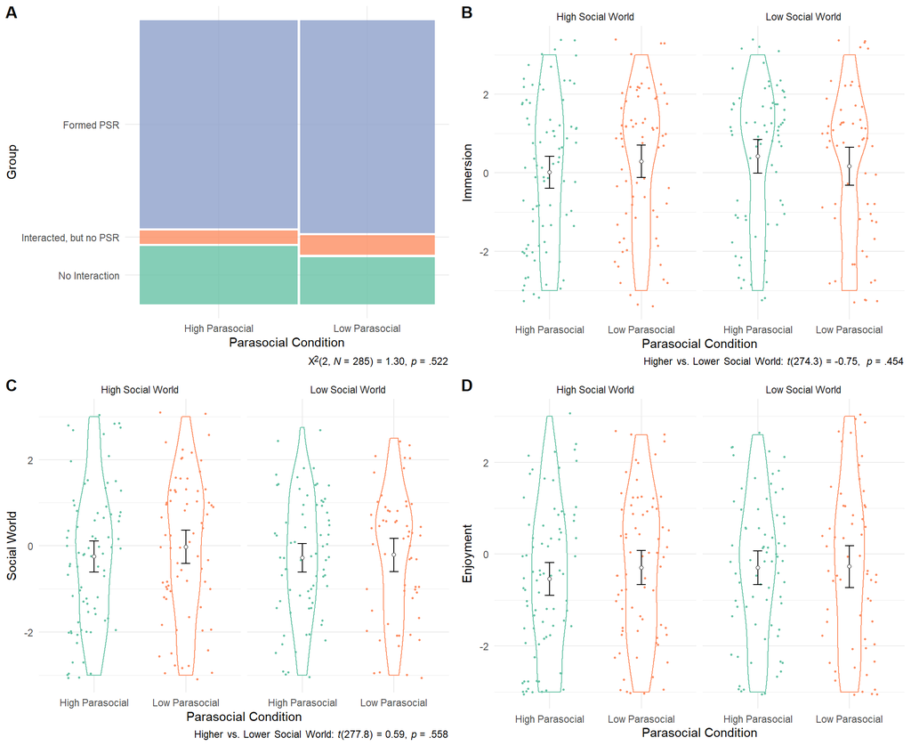

Figure 4.2: Study 3 - Exploratory Manipulation Check

```r
# Parasocial Relationship Manipulation Check plot
s3_parasocial_plot <- s3_df %>%
  filter(attention_all_correct == TRUE) %>%
  # Modify labels
  mutate(parasocial_MC_group_shortlabel =
           case_when(parasocial_MC_group == "No Interaction with NPC" ~ "No Interaction",
                     parasocial_MC_group == "No Parasocial Relationship with NPC" ~ "Interacted, but no PSR",
                     parasocial_MC_group == "Formed Parasocial Relationship with NPC" ~ "Formed PSR"),
         parasocial_MC_group_shortlabel = factor(parasocial_MC_group_shortlabel,
                                                 ordered = TRUE,
                                                 levels = c("No Interaction",
                                                            "Interacted, but no PSR",
                                                            "Formed PSR"))) %>%
  ggplot() +
  geom_mosaic(aes(x = product(parasocial_MC_group_shortlabel, parasocial), fill = parasocial_MC_group_shortlabel)) +
  ylab("Group") +
  xlab("Parasocial Condition") +
  scale_fill_brewer(name = "Group", palette = "Set2") +
  # Remove the legend
  guides(fill = FALSE) +
  theme(plot.caption = element_markdown(lineheight = 1.2)) +
  labs(caption = s3_manicheck_APA$parasocial_chi)
# facet_wrap(.~social_world)


# Plot for the immersion
s3_immersion_plot <- s3_df %>%
  # Exclude those failed attention check
  filter(attention_all_correct == TRUE) %>%
  ggplot(aes(x = parasocial, y = Single_Immersion, color = parasocial)) +
  # Default violin, errorbar plot
  default_violin +
  # Remove legend
  guides(color = FALSE) +
  # Labels
  ylab("Immersion") +
  xlab("Parasocial Condition") +
  # Condition value labels to title case
  scale_x_discrete(labels = str_to_title) +
  # Facet by Social World
  facet_grid(. ~ social_world) +
  labs(caption = paste("Higher vs. Lower Social World:", s3_manicheck_APA$immersion))


# Plot - OTF World
s3_OTFWorld_plot <- s3_df %>%
  # Exclude those failed attention check
  filter(attention_all_correct == TRUE) %>%
  ggplot(aes(x = parasocial, y = OTF_Social_World, color = parasocial)) +
  # violin
  default_violin +
  # Remove legend
  guides(color = FALSE) +
  # Labels
  ylab("Social World") +
  xlab("Parasocial Condition") +
  # Condition value labels to title case
  scale_x_discrete(labels = str_to_title) +
  # Facet by Social World
  facet_grid(. ~ social_world) +
  labs(caption = paste("Higher vs. Lower Social World:", s3_manicheck_APA$OTFWorld))

# Plot - Enjoyment
s3_Enjoyment_plot <- s3_df %>%
  # Exclude those failed attention check
  filter(attention_all_correct == TRUE) %>%
  ggplot(aes(x = parasocial, y = Enjoyment, color = parasocial)) +
  # violin
  default_violin +
  # Remove legend
  guides(color = FALSE) +
  # Labels
  ylab("Enjoyment") +
  xlab("Parasocial Condition") +
  # Condition value labels to title case
  scale_x_discrete(labels = str_to_title) +
  # Facet by Social World
  facet_grid(. ~ social_world)


# Gather plots into one plot ------------------------------------------------
ggarrange(s3_parasocial_plot,
          s3_immersion_plot,
          s3_OTFWorld_plot,
          s3_Enjoyment_plot,
          labels = "AUTO")
```

```r
# Gender
# Group to Female, Male, and Non-Female & Male.
moderation_gender_lm <- s3_df %>%
  lm(formula = T2_Heart_1 ~ parasocial_EC*social_world_EC*Gender_Identity_2GP_EC)
## Gender Identity 2 GP?

# Race
moderation_race_lm <- s3_df %>%
  lm(formula = T2_Heart_1 ~ parasocial*social_world*Race_6GP)

## Add APA-Style Texts
### Gender
# emmeans(moderation_gender_lm, pairwise ~ parasocial:social_world:Gender_Identity_3GP, level = .90)
moderation_gender_APA <- describe.glm(moderation_gender_lm, dtype = 3) %>%
  select(eff, str) %>% deframe_as_list()
### Race
moderation_race_APA <- describe.glm(moderation_race_lm, dtype = 3) %>%
  select(eff, str) %>% deframe_as_list()
```

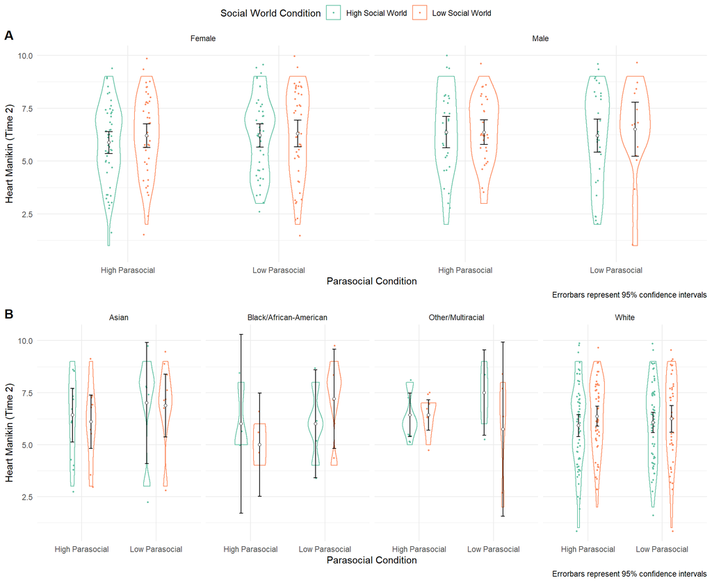

Figure 4.3: Study 3 - Moderation Analysis

```r
# Moderation by Gender - Plot ----------------------------------------------------
s3_mod_by_gender_plot <- s3_df %>%
  # Exclude those who failed attention check
  filter(attention_all_correct == TRUE) %>%
  # Exclude people identifying other than male or female (since htere are too few)
  filter(Gender_Identity_3GP != "Other") %>%
  ggplot(aes(x = parasocial,
             y = T2_Heart_1,
             color = social_world)) +
  # violin
  geom_violin(width = default_violin_width,
              position = dodge_pos) +
  # Data points
  geom_point(position = position_jitterdodge(jitter.height = 1,
                                             jitter.width = .05, dodge.width = my_dodge_width),
             size = .5) +
  # Errorbar
  geom_errorbar(aes(group = social_world), fun.data = mean_cl_normal,
                stat = "summary",
                width = .1,
                position = dodge_pos,
                color = "black", alpha = 1) +
  # Plot means
  geom_point(aes(group = social_world), stat = "summary", fun.data = mean_cl_normal,
             shape = 21, fill = "white",
             color = "black", position = dodge_pos) +
  # Labels
  labs(y = "Heart Manikin (Time 2)",
       x = "Parasocial Condition",
       color = "Social World Condition",
       caption = "Errorbars represent 95% confidence intervals") +
  # Color Palette
      scale_color_brewer(palette = "Set2") +
  facet_grid(. ~ Gender_Identity_3GP)
  # Save Plot
  #ggsave(here("plot","s3_heart2_plot.png"), width = 6, height = 4)

# Moderation by Race - Plot ----------------------------------------------------
# Visualize
s3_mod_by_race_plot <- s3_df %>%
  # Exclude those who failed attention check
  filter(attention_all_correct == TRUE) %>%
  ggplot(aes(x = parasocial,
             y = T2_Heart_1,
             color = social_world)) +
  # violin
  geom_violin(width = default_violin_width,
              position = dodge_pos) +
  # Data points
  geom_point(position = position_jitterdodge(jitter.height = 1,
                                             jitter.width = .05, dodge.width = my_dodge_width),
             size = .5) +
  # Errorbar
  geom_errorbar(aes(group = social_world), fun.data = mean_cl_normal,
                stat = "summary",
                width = .1,
                position = dodge_pos,
                color = "black", alpha = 1) +
  # Plot means
  geom_point(aes(group = social_world), stat = "summary", fun.data = mean_cl_normal,
             shape = 21, fill = "white",
             color = "black", position = dodge_pos) +
  # Labels
  labs(y = "Heart Manikin (Time 2)",
       x = "Parasocial Condition",
       color = "Social World Condition",
       caption = "Errorbars represent 95% confidence intervals") +
  # Color Palette
      scale_color_brewer(palette = "Set2") +
  # Facet by gender identity
  facet_grid(.~Race_6GP)

# Arrange the gender and race plots into one
ggarrange(s3_mod_by_gender_plot,
          s3_mod_by_race_plot,
          nrow = 2, legend = "top", common.legend = TRUE, labels = "AUTO")
```

```r
# Create a long dataset for all manikin variables
s3_df_long <-s3_df %>%
  filter(attention_all_correct == TRUE) %>%
  pivot_longer(cols = c(starts_with("T1"), starts_with("T2"))) %>%
  mutate(name = str_remove(name, "_1")) %>%
  mutate(time = str_extract(name, "T\\d"),
         # Get the name followed by _
         repvarname = str_extract(name, "(?:[^_](?!_))+$")) %>%
  # Pivoting to wider, one row per observation, retaining conditions labels
  pivot_wider(id_cols = c(ResponseId, parasocial, social_world, time), names_from = repvarname)

# Mixed Anova model
s3_manikins_time <- tibble(outcome = c("Heart", "Valence", "Arousal", "Dominance")) %>%
  mutate(fit = map(outcome, ~rstatix::anova_test(data = s3_df_long, dv = .,
                                                 wid = ResponseId, between = c(parasocial, social_world),
                                                 within = time)),
         APA = map(fit, function(x){as.tibble(x)})) %>%
  # Go through the tibble to create the APA -compatible string
  mutate(APA = map(APA, function(x){x %>%
      mutate(APA = sprintf("_F_(%s, %s) = %s, _p_ %s, &eta;<sup>2</sup> %s",
                           DFn, DFd, F %>% f.round(),
                           p %>% round.p(),
                           round.p(ges)))}))
# Time meansd
s3_time_msd <- s3_df_long %>%
  describe_by_factor(time, vars = c(Heart, Valence, Arousal, Dominance)) %>%
  get_APA_from_msd
## APA for Tiem comparisons
s3_time_APA <-  s3_time_msd %>% mutate(label = str_c(time, variable)) %>%
  select(label, APA) %>% deframe_as_list()

# APA
s3_manikins_time <- NA
```

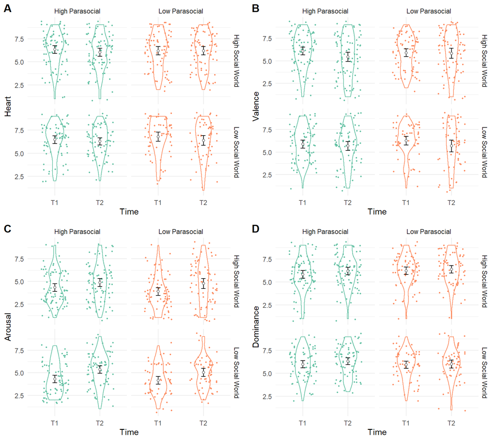

Figure 4.4: Study 3 - Mankin Scores Across Time By Conditions

```r
# Plot the changes
# Heart
draw_s3_manikin_plot <- function(outcome){
  s3_df_long %>%
  ggplot(aes(x = time, y = {{outcome}}, color = parasocial)) +
  # Add Defeault violin plot
  default_violin +
  # Facet
  facet_grid(social_world ~ parasocial) +
  # labels
  labs(color = "Parasocial Condition",
       x = "Time")
}

# Gather the plots into one
ggarrange(draw_s3_manikin_plot(Heart),
          draw_s3_manikin_plot(Valence),
          draw_s3_manikin_plot(Arousal),
          draw_s3_manikin_plot(Dominance),
          labels = "AUTO", common.legend = TRUE, legend = "none")
```